# CA5_810197668

```python
import torchvision
import torchvision.transforms as transforms
```

```python
import torch
```

```python
device = torch.device("cpu")
device
```

```
device(type='cpu')
```

# تابع تست برای بدست آوردن میزان خطا

```python
def test_it(testloader, net):
  correct = 0
  total = 0
  with torch.no_grad():
      for data in testloader:
          images, labels = data
          outputs = net(images)
          _, predicted = torch.max(outputs.data, 1)
          total += labels.size(0)
          correct += (predicted == labels).sum().item()

  print('Accuracy of the network on the 10000 test images: %d %%' % (
      100 * correct / total))

  return 100 * correct / total
```

# تعریف شبکه

دو لایه کانولوشن - سه لایه خطی - لایه ی خطی آخر لایه خروجی است

```python
import torch.nn as nn
import torch.nn.functional as F


class Net(nn.Module):
    def __init__(self):
        super(Net, self).__init__()
        self.conv1 = nn.Conv2d(3, 6, 5)
        self.pool = nn.MaxPool2d(2, 2)
        self.conv2 = nn.Conv2d(6, 16, 5)
        self.fc1 = nn.Linear(16 * 5 * 5, 120)
        self.fc2 = nn.Linear(120, 84)
        self.fc3 = nn.Linear(84, 10)

    def forward(self, x):
        x = self.pool(F.relu(self.conv1(x)))
        x = self.pool(F.relu(self.conv2(x)))
        x = x.view(-1, 16 * 5 * 5)
        x = F.relu(self.fc1(x))
        x = F.relu(self.fc2(x))
        x = self.fc3(x)
        return x


net = Net()
```

# تابع برای مقدار دهی رندوم به وزن ها

```python
def init_weights(m):
  if type(m) == nn.Linear or type(m) == nn.Conv2d:
    torch.nn.init.xavier_uniform(m.weight)
```

این تابع را روی شبکه اجرا می کنیم تا وزن ها رندوم شوند

```python
net.apply(init_weights)
```

```
Net(
  (conv1): Conv2d(3, 6, kernel_size=(5, 5), stride=(1, 1))
  (pool): MaxPool2d(kernel_size=2, stride=2, padding=0, dilation=1, ceil_mode=False)
  (conv2): Conv2d(6, 16, kernel_size=(5, 5), stride=(1, 1))
  (fc1): Linear(in_features=400, out_features=120, bias=True)
  (fc2): Linear(in_features=120, out_features=84, bias=True)
  (fc3): Linear(in_features=84, out_features=10, bias=True)
)
```

```python
%time losses = train_data(trainloader, net, 5)
```

[output not shown]

```python
test_it(trainloader, net)
```

```
Accuracy of the network on the 10000 test images: 6 %
```

```
6.36
```

مبدل ای که صرفا تایپ را تغییر می دهد

```python
transform = transforms.Compose(
    [transforms.ToTensor()])
```

خواندن داده با مبدل تعریف شده و بچ سایز ۳۲

```python
trainset = torchvision.datasets.CIFAR10(root='./data', train=True,
                                        download=True, transform=transform)

trainloader = torch.utils.data.DataLoader(trainset, batch_size=32,
                                          shuffle=True, num_workers=2)

testset = torchvision.datasets.CIFAR10(root='./data', train=False,
                                       download=True, transform=transform)

testloader = torch.utils.data.DataLoader(testset, batch_size=32,
                                         shuffle=False, num_workers=2)


classes = ('plane', 'car', 'bird', 'cat',
           'deer', 'dog', 'frog', 'horse', 'ship', 'truck')
```

```
Files already downloaded and verified
Files already downloaded and verified
```

# نمایش داده ها

```python
import matplotlib.pyplot as plt
import numpy as np

# functions to show an image


def my_imshow(img):
    img = img / 2 + 0.5     # unnormalize
    npimg = img.numpy()
    plt.imshow(np.transpose(npimg, (1, 2, 0)))
    plt.show()
```

```python
dataiter = iter(trainloader)
images, labels = dataiter.next()
images.size()
```

```
torch.Size([32, 3, 32, 32])
```

```python
labels
```

```
tensor([0, 1, 1, 3, 5, 9, 2, 8, 7, 8, 7, 4, 1, 7, 4, 6, 4, 1, 9, 5, 4, 4, 6, 2,
        7, 0, 5, 0, 5, 8, 0, 7])
```

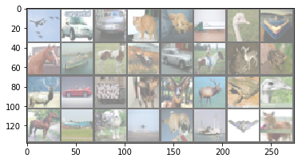

```python
my_imshow(torchvision.utils.make_grid(images))
```

# تابعی که آموزش می دهد

```python
import torch.optim as optim

def train_data(trainloader, net, epoch_numbers,
                criterion = nn.CrossEntropyLoss(),
                optimizer = optim.SGD(net.parameters(), lr=0.001, momentum=0.9)):

    losses = []
    for epoch in range(epoch_numbers):

        running_loss = 0.0
        for i, data in enumerate(trainloader, 0):
          inputs, labels = data
          optimizer.zero_grad()

          outputs = net(inputs)
          loss = criterion(outputs, labels)
          loss.backward()
          optimizer.step()
          losses.append(loss.item())

          running_loss += loss.item()
          if i % 500 == 499:
            print('[%d, %5d] loss: %.3f' %
                    (epoch + 1, i + 1, running_loss / 500))
            running_loss = 0.0

    print("Finished Training")
    return losses
```

آموزش شبکه با داده مشخص و تابع آموزش مشخص شده

[figure not shown]

```
GroundTruth:    cat  ship  ship plane  frog  frog   car  frog   cat   car plane truck   dog horse truck  ship   dog horse  ship  frog horse plane  deer truck   dog  bird  deer plane truck  frog  frog   dog
```

```python
dataiter = iter(testloader)
images, labels = dataiter.next()

# print images
my_imshow(torchvision.utils.make_grid(images))
print('GroundTruth: ', ' '.join('%5s' % classes[labels[j]] for j in range(32)))
```

```python
outputs = net(images)
```

```python
_, predicted = torch.max(outputs, 1)

print('Predicted: ', ' '.join('%5s' % classes[predicted[j]]
                              for j in range(32)))
```

```
Predicted:    cat  ship  ship  ship  deer  frog   cat  frog   dog   car  ship truck  frog horse   car  ship   car   cat  ship  frog horse plane plane   car  deer  bird  frog  bird truck  frog  frog   dog
```

```python
%time losses = train_data(trainloader, net, 5)
```

```
[1,   500] loss: 0.838
[1,  1000] loss: 0.810
[1,  1500] loss: 0.795
[2,   500] loss: 0.762
[2,  1000] loss: 0.770
[2,  1500] loss: 0.773
[3,   500] loss: 0.748
[3,  1000] loss: 0.760
[3,  1500] loss: 0.743
[4,   500] loss: 0.726
[4,  1000] loss: 0.742
[4,  1500] loss: 0.734
[5,   500] loss: 0.712
[5,  1000] loss: 0.720
[5,  1500] loss: 0.717
Finished Training
CPU times: user 1min 42s, sys: 7.16 s, total: 1min 49s
Wall time: 1min 53s
```

```python
test_it(trainloader, net)
```

```
Accuracy of the network on the 10000 test images: 75 %
```

```
75.466
```

```python
net
```

[output not shown]

```python
def init_weights(m):
  if type(m) == nn.Linear or type(m) == nn.Conv2d:
    m.weight.data.fill_(0)

net.apply(init_weights)
```

[output not shown]

```python
losses = train_data(trainloader, net, 5)
```

```
[1,   500] loss: 2.302
[2,   500] loss: 2.300
[3,   500] loss: 2.277
[4,   500] loss: 2.115
[5,   500] loss: 1.983
Finished Training
```

```python
test_it(testloader, net)
```

```
Accuracy of the network on the 10000 test images: 19 %
```

```
19.04
```

```python
from math import floor

def make_net_2_layer(channels_number=6, filter_size=5, pooling_window_size=2):

  output_shape = ((32 - filter_size + 1) - pooling_window_size) / 2 + 1
  if int(((32 - filter_size + 1) - pooling_window_size) / 2 + 1) != float(((32 - filter_size + 1) - pooling_window_size) / 2 + 1):
    return None

  class Net(nn.Module):

    def __init__(self):
      super(Net, self).__init__()
      self.conv1 = nn.Conv2d(3, channels_number, filter_size)
      self.pool = nn.MaxPool2d(pooling_window_size)
      self.fc1 = nn.Linear(channels_number * int(output_shape) * int(output_shape), 10)

    def forward(self, x):
      x = self.pool(F.relu(self.conv1(x)))
      x = x.view(-1, channels_number * int(output_shape) * int(output_shape))
      x = self.fc1(x)
      return x

  return Net()
```

```python
channels_number = 5
max_accuracy = 0

for curr_channels_number in range(5, 16):
  curr_net = make_net_2_layer(curr_channels_number)
  if curr_net != None:
    curr_net.apply(init_weights)
    train_data(trainloader, curr_net, 5)
    curr_accuracy = test_it(testloader, curr_net)

    if curr_accuracy > max_accuracy:
      channels_number = curr_channels_number
      max_accuracy = curr_accuracy


print('Max Accuracy of the network on the 10000 test images: %d %%' % (
      max_accuracy))
print(channels_number)
```

```
[1,   500] loss: 2.461
[1,  1000] loss: 2.472
[1,  1500] loss: 2.468
[2,   500] loss: 2.464
[2,  1000] loss: 2.475
[2,  1500] loss: 2.466
[3,   500] loss: 2.463
[3,  1000] loss: 2.471
[3,  1500] loss: 2.468
[4,   500] loss: 2.471
[4,  1000] loss: 2.464
[4,  1500] loss: 2.466
[5,   500] loss: 2.466
[5,  1000] loss: 2.466
[5,  1500] loss: 2.469
```

[output cut: 174 more lines]

مناسب ترین تعداد کانال خروجی ۱۰ است

```python
filter_size = 3
max_accuracy = 0

for curr_filter_size in range(3, 10):
  curr_net = make_net_2_layer(channels_number=10, filter_size=curr_filter_size)
  if curr_net != None:
    curr_net.apply(init_weights)
    train_data(trainloader, curr_net, 5)
    curr_accuracy = test_it(testloader, curr_net)

    if curr_accuracy > max_accuracy:
      filter_size = curr_filter_size
      max_accuracy = curr_accuracy


print('Max Accuracy of the network on the 10000 test images: %d %%' % (
      max_accuracy))
print(filter_size)
```

```
[1,   500] loss: 2.368
[1,  1000] loss: 2.364
[1,  1500] loss: 2.362
[2,   500] loss: 2.365
[2,  1000] loss: 2.364
[2,  1500] loss: 2.367
[3,   500] loss: 2.365
[3,  1000] loss: 2.363
[3,  1500] loss: 2.366
[4,   500] loss: 2.368
[4,  1000] loss: 2.364
[4,  1500] loss: 2.363
[5,   500] loss: 2.367
[5,  1000] loss: 2.364
[5,  1500] loss: 2.363
```

[output cut: 55 more lines]

بهترین سایز فیلتر ۷ در ۷ است

```python
transform = transforms.Compose(
    [transforms.ToTensor(),
     transforms.Normalize((0.5, 0.5, 0.5), (0.5, 0.5, 0.5))])

trainset = torchvision.datasets.CIFAR10(root='./data', train=True,
                                        download=True, transform=transform)

trainloader = torch.utils.data.DataLoader(trainset, batch_size=32,
                                          shuffle=True, num_workers=2)

testset = torchvision.datasets.CIFAR10(root='./data', train=False,
                                       download=True, transform=transform)

testloader = torch.utils.data.DataLoader(testset, batch_size=32,
                                         shuffle=False, num_workers=2)

classes = ('plane', 'car', 'bird', 'cat',
           'deer', 'dog', 'frog', 'horse', 'ship', 'truck')
```

```
Files already downloaded and verified
Files already downloaded and verified
```

```python
import torch.nn as nn
import torch.nn.functional as F


class Net(nn.Module):
    def __init__(self):
        super(Net, self).__init__()
        self.conv1 = nn.Conv2d(3, 6, 5)
        self.pool = nn.MaxPool2d(2, 2)
        self.conv2 = nn.Conv2d(6, 16, 5)
        self.fc1 = nn.Linear(16 * 5 * 5, 120)
        self.fc2 = nn.Linear(120, 84)
        self.fc3 = nn.Linear(84, 10)

    def forward(self, x):
        x = self.pool(F.relu(self.conv1(x)))
        x = self.pool(F.relu(self.conv2(x)))
        x = x.view(-1, 16 * 5 * 5)
        x = F.relu(self.fc1(x))
        x = F.relu(self.fc2(x))
        x = self.fc3(x)
        return x


net = Net()
```

```python
def init_weights(m):
  if type(m) == nn.Linear or type(m) == nn.Conv2d:
    torch.nn.init.xavier_uniform(m.weight)

net.apply(init_weights)
```

[output not shown]

```python
%time train_data(trainloader, net, 5, optimizer = optim.SGD(net.parameters(), lr=0.01, momentum=0.9))
test_it(testloader, net)
```

```
[1,   500] loss: 1.399
[1,  1000] loss: 1.333
[1,  1500] loss: 1.276
[2,   500] loss: 1.194
[2,  1000] loss: 1.176
[2,  1500] loss: 1.148
[3,   500] loss: 1.093
[3,  1000] loss: 1.074
[3,  1500] loss: 1.070
[4,   500] loss: 0.995
[4,  1000] loss: 1.016
[4,  1500] loss: 1.020
[5,   500] loss: 0.940
[5,  1000] loss: 0.965
[5,  1500] loss: 0.961
Finished Training
CPU times: user 1min 47s, sys: 7.61 s, total: 1min 54s
Wall time: 2min 2s
Accuracy of the network on the 10000 test images: 62 %
```

```
62.2
```

وقتی داده را نرمالایز می کنیم دقت بالا می رود اما زمان آموزش بیشتر می شود

```python
import torch.nn as nn
import torch.nn.functional as F


class Net_1(nn.Module):
    def __init__(self):
        super(Net_1, self).__init__()
        self.conv1 = nn.Conv2d(3, 6, 5)
        self.pool = nn.MaxPool2d(2, 2)
        self.conv2 = nn.Conv2d(6, 16, 5)
        self.fc1 = nn.Linear(16 * 5 * 5, 120)
        self.fc2 = nn.Linear(120, 84)
        self.fc3 = nn.Linear(84, 10)

    def forward(self, x):
        x = self.pool(F.relu(self.conv1(x)))
        x = self.pool(F.relu(self.conv2(x)))
        x = x.view(-1, 16 * 5 * 5)
        x = F.relu(self.fc1(x))
        x = F.relu(self.fc2(x))
        x = self.fc3(x)
        return x


net = Net_1()
```

```python
transform = transforms.Compose(
    [transforms.ToTensor(),
     transforms.Normalize((0.5, 0.5, 0.5), (0.5, 0.5, 0.5))])

trainset = torchvision.datasets.CIFAR10(root='./data', train=True,
                                        download=True, transform=transform)

trainloader = torch.utils.data.DataLoader(trainset, batch_size=32,
                                          shuffle=True, num_workers=2)

testset = torchvision.datasets.CIFAR10(root='./data', train=False,
                                       download=True, transform=transform)

testloader = torch.utils.data.DataLoader(testset, batch_size=32,
                                         shuffle=False, num_workers=2)

classes = ('plane', 'car', 'bird', 'cat',
           'deer', 'dog', 'frog', 'horse', 'ship', 'truck')

learning_rates = [3, 0.03, 0.0003]

losses_function = []

for i, _lr in enumerate(learning_rates):

#   net.apply(init_weights)
  net = Net_1()

  %time losses_function.append(train_data(trainloader, net, 5, optimizer = optim.SGD(net.parameters(), lr=_lr, momentum=0.9)))
  test_it(testloader, net)
```

```
Files already downloaded and verified
Files already downloaded and verified
```

[output not shown]

```
[1,   500] loss: 2.563
[1,  1000] loss: 2.552
[1,  1500] loss: 2.552
[2,   500] loss: 2.534
[2,  1000] loss: 2.566
[2,  1500] loss: 2.541
[3,   500] loss: 2.568
[3,  1000] loss: 2.547
[3,  1500] loss: 2.546
[4,   500] loss: 2.572
[4,  1000] loss: 2.551
[4,  1500] loss: 2.553
[5,   500] loss: 2.544
[5,  1000] loss: 2.582
[5,  1500] loss: 2.532
```

[output cut: 42 more lines]

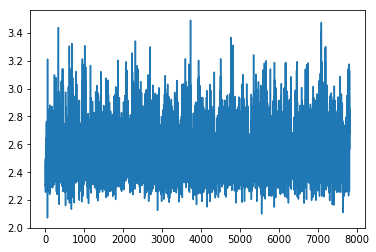

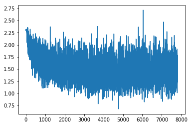

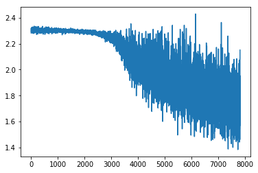

```python
for losses in losses_function:
  plt.plot(losses)
  plt.show()
```

```python
trainset = torchvision.datasets.CIFAR10(root='./data', train=True,
                                        download=True, transform=transform)

trainloader = torch.utils.data.DataLoader(trainset, batch_size=64,
                                          shuffle=True, num_workers=2)

testset = torchvision.datasets.CIFAR10(root='./data', train=False,
                                       download=True, transform=transform)

testloader = torch.utils.data.DataLoader(testset, batch_size=64,
                                         shuffle=False, num_workers=2)


classes = ('plane', 'car', 'bird', 'cat',
           'deer', 'dog', 'frog', 'horse', 'ship', 'truck')
```

```
Files already downloaded and verified
Files already downloaded and verified
```

```python
net = Net_1()
net.apply(init_weights)
```

```
Net_1(
  (conv1): Conv2d(3, 6, kernel_size=(5, 5), stride=(1, 1))
  (pool): MaxPool2d(kernel_size=2, stride=2, padding=0, dilation=1, ceil_mode=False)
  (conv2): Conv2d(6, 16, kernel_size=(5, 5), stride=(1, 1))
  (fc1): Linear(in_features=400, out_features=120, bias=True)
  (fc2): Linear(in_features=120, out_features=84, bias=True)
  (fc3): Linear(in_features=84, out_features=10, bias=True)
)
```

```python
%time train_data(trainloader, net, 5, optimizer = optim.SGD(net.parameters(), lr=0.01, momentum=0.9))
test_it(testloader, net)
```

```
[1,   500] loss: 1.012
[2,   500] loss: 0.964
[3,   500] loss: 0.919
[4,   500] loss: 0.884
[5,   500] loss: 0.845
Finished Training
CPU times: user 1min 14s, sys: 5.5 s, total: 1min 20s
Wall time: 1min 23s
Accuracy of the network on the 10000 test images: 60 %
```

```
60.24
```

```python
%time train_data(trainloader, net, 5, optimizer = optim.SGD(net.parameters(), lr=1, momentum=0.9))
test_it(testloader, net)
```

```
[1,   500] loss: 1836.112
[2,   500] loss: 2.333
[3,   500] loss: 2.343
[4,   500] loss: 2.339
[5,   500] loss: 2.336
Finished Training
CPU times: user 1min 15s, sys: 5.53 s, total: 1min 20s
Wall time: 1min 24s
Accuracy of the network on the 10000 test images: 10 %
```

```
10.0
```

```python
trainset = torchvision.datasets.CIFAR10(root='./data', train=True,
                                        download=True, transform=transform)

trainloader = torch.utils.data.DataLoader(trainset, batch_size=256,
                                          shuffle=True, num_workers=2)

testset = torchvision.datasets.CIFAR10(root='./data', train=False,
                                       download=True, transform=transform)

testloader = torch.utils.data.DataLoader(testset, batch_size=256,
                                         shuffle=False, num_workers=2)


classes = ('plane', 'car', 'bird', 'cat',
           'deer', 'dog', 'frog', 'horse', 'ship', 'truck')
```

```
Files already downloaded and verified
Files already downloaded and verified
```

```python
%time train_data(trainloader, net, 5, optimizer = optim.SGD(net.parameters(), lr=0.01, momentum=0.9))
test_it(testloader, net)
```

```
Finished Training
CPU times: user 1min 5s, sys: 4.36 s, total: 1min 9s
Wall time: 1min 12s
Accuracy of the network on the 10000 test images: 55 %
```

```
55.74
```

```python
%time train_data(trainloader, net, 5, optimizer = optim.SGD(net.parameters(), lr=1, momentum=0.9))
test_it(testloader, net)
```

```
Finished Training
CPU times: user 1min 3s, sys: 4.54 s, total: 1min 8s
Wall time: 1min 10s
Accuracy of the network on the 10000 test images: 10 %
```

```
10.0
```

```python
import torch.nn as nn
import torch.nn.functional as F


class Net_2(nn.Module):
    def __init__(self, _aFunc):
        self.aFunc = _aFunc
        super(Net_2, self).__init__()
        self.conv1 = nn.Conv2d(3, 6, 5)
        self.pool = nn.MaxPool2d(2, 2)
        self.conv2 = nn.Conv2d(6, 16, 5)
        self.fc1 = nn.Linear(16 * 5 * 5, 120)
        self.fc2 = nn.Linear(120, 84)
        self.fc3 = nn.Linear(84, 10)

    def forward(self, x):
        x = self.pool(self.aFunc(self.conv1(x)))
        x = self.pool(self.aFunc(self.conv2(x)))
        x = x.view(-1, 16 * 5 * 5)
        x = self.aFunc(self.fc1(x))
        x = self.aFunc(self.fc2(x))
        x = self.fc3(x)
        return x
```

```python
trainset = torchvision.datasets.CIFAR10(root='./data', train=True,
                                        download=True, transform=transform)

trainloader = torch.utils.data.DataLoader(trainset, batch_size=64,
                                          shuffle=True, num_workers=2)

testset = torchvision.datasets.CIFAR10(root='./data', train=False,
                                       download=True, transform=transform)

testloader = torch.utils.data.DataLoader(testset, batch_size=64,
                                         shuffle=False, num_workers=2)


classes = ('plane', 'car', 'bird', 'cat',
           'deer', 'dog', 'frog', 'horse', 'ship', 'truck')
```

```
Files already downloaded and verified
Files already downloaded and verified
```

```python
net = Net_2(F.tanh)
%time train_data(trainloader, net, 5, optimizer = optim.SGD(net.parameters(), lr=0.01, momentum=0.9))
test_it(testloader, net)
```

```
[1,   500] loss: 1.829
[2,   500] loss: 1.371
[3,   500] loss: 1.228
[4,   500] loss: 1.152
[5,   500] loss: 1.076
Finished Training
CPU times: user 1min 21s, sys: 6.72 s, total: 1min 28s
Wall time: 1min 31s
Accuracy of the network on the 10000 test images: 59 %
```

```
59.89
```

```python
net = Net_2(F.leaky_relu)
%time train_data(trainloader, net, 5, optimizer = optim.SGD(net.parameters(), lr=0.01, momentum=0.9))
test_it(testloader, net)
```

```
[1,   500] loss: 1.939
[2,   500] loss: 1.423
[3,   500] loss: 1.249
[4,   500] loss: 1.135
[5,   500] loss: 1.045
Finished Training
CPU times: user 1min 24s, sys: 7.55 s, total: 1min 32s
Wall time: 1min 35s
Accuracy of the network on the 10000 test images: 61 %
```

```
61.21
```

```python
net = Net_2(F.softplus)
%time train_data(trainloader, net, 5, optimizer = optim.SGD(net.parameters(), lr=0.01, momentum=0.9))
test_it(testloader, net)
```

```
[1,   500] loss: 2.311
[2,   500] loss: 1.814
[3,   500] loss: 1.515
[4,   500] loss: 1.376
[5,   500] loss: 1.277
Finished Training
CPU times: user 2min 59s, sys: 4.92 s, total: 3min 4s
Wall time: 3min 7s
Accuracy of the network on the 10000 test images: 55 %
```

```
55.89
```

```python
import torch.nn as nn
import torch.nn.functional as F


class Net_3(nn.Module):
    def __init__(self, _aFunc):
        self.aFunc = _aFunc
        super(Net_2, self).__init__()
        self.conv1 = nn.Conv2d(3, 6, 5)
        self.pool = nn.MaxPool2d(2, 2)
        self.conv2 = nn.Conv2d(6, 16, 5)
        self.conv2_bn = nn.BatchNorm2d(16)
        self.fc1 = nn.Linear(16 * 5 * 5, 120)
        self.fc2 = nn.Linear(120, 84)
        self.fc3 = nn.Linear(84, 10)

    def forward(self, x):
        x = self.pool(self.aFunc(self.conv1(x)))
        x = self.pool(self.aFunc(self.conv2_bn(self.conv2(x))))
        x = x.view(-1, 16 * 5 * 5)
        x = self.aFunc(self.fc1(x))
        x = self.aFunc(self.fc2(x))
        x = self.fc3(x)
        return x
```

```python
net = Net_2(F.leaky_relu)
%time train_data(trainloader, net, 5, optimizer = optim.SGD(net.parameters(), lr=0.01, momentum=0.9))
test_it(testloader, net)
```

```
[1,   500] loss: 1.733
[2,   500] loss: 1.329
[3,   500] loss: 1.188
[4,   500] loss: 1.102
[5,   500] loss: 1.028
Finished Training
CPU times: user 1min 34s, sys: 6.11 s, total: 1min 40s
Wall time: 1min 43s
Accuracy of the network on the 10000 test images: 60 %
```

```
60.19
```

```python
transform = transforms.Compose(
    [transforms.ToTensor(),
     transforms.Normalize((0.5, 0.5, 0.5), (0.5, 0.5, 0.5))])

trainset = torchvision.datasets.CIFAR10(root='./data', train=True,
                                        download=True, transform=transform)

trainloader = torch.utils.data.DataLoader(trainset, batch_size=32,
                                          shuffle=True, num_workers=2)

testset = torchvision.datasets.CIFAR10(root='./data', train=False,
                                       download=True, transform=transform)

testloader = torch.utils.data.DataLoader(testset, batch_size=32,
                                         shuffle=False, num_workers=2)

classes = ('plane', 'car', 'bird', 'cat',
           'deer', 'dog', 'frog', 'horse', 'ship', 'truck')

net = Net_2(F.leaky_relu)
%time train_data(trainloader, net, 5, optimizer = optim.SGD(net.parameters(), lr=0.01, momentum=0.9))
test_it(testloader, net)
```

```
Files already downloaded and verified
Files already downloaded and verified
[1,   500] loss: 2.026
[1,  1000] loss: 1.639
[1,  1500] loss: 1.503
[2,   500] loss: 1.393
[2,  1000] loss: 1.333
[2,  1500] loss: 1.316
[3,   500] loss: 1.218
[3,  1000] loss: 1.206
[3,  1500] loss: 1.191
[4,   500] loss: 1.114
[4,  1000] loss: 1.117
[4,  1500] loss: 1.108
[5,   500] loss: 1.037
[5,  1000] loss: 1.048
[5,  1500] loss: 1.057
Finished Training
CPU times: user 1min 36s, sys: 7.12 s, total: 1min 43s
Wall time: 1min 51s
Accuracy of the network on the 10000 test images: 60 %
```

```
60.2
```

```python
net = Net_2(F.leaky_relu)
%time train_data(trainloader, net, 5, optimizer = optim.SGD(net.parameters(), lr=0.01))
test_it(testloader, net)
```

```
[1,   500] loss: 2.303
[1,  1000] loss: 2.298
[1,  1500] loss: 2.267
[2,   500] loss: 2.028
[2,  1000] loss: 1.925
[2,  1500] loss: 1.796
[3,   500] loss: 1.693
[3,  1000] loss: 1.637
[3,  1500] loss: 1.578
[4,   500] loss: 1.529
[4,  1000] loss: 1.514
[4,  1500] loss: 1.477
[5,   500] loss: 1.443
[5,  1000] loss: 1.417
[5,  1500] loss: 1.402
Finished Training
CPU times: user 1min 33s, sys: 7.06 s, total: 1min 40s
Wall time: 1min 48s
Accuracy of the network on the 10000 test images: 50 %
```

```
50.38
```

مومنتوم پیش فرض صفر است و این خوب نیست چون اگر در یک بعد بخواهیم با سرعت زیاد حرکت کنیم این امکان پذیر نخواهد بود اما اگر مومنتوم نزدیک یک باشد خیلی بهتر است زیرا اگر بخواهیم می توانیم در یک بعد با سرعت حرکت کنیم